# PCA GMD_Reshaping Data

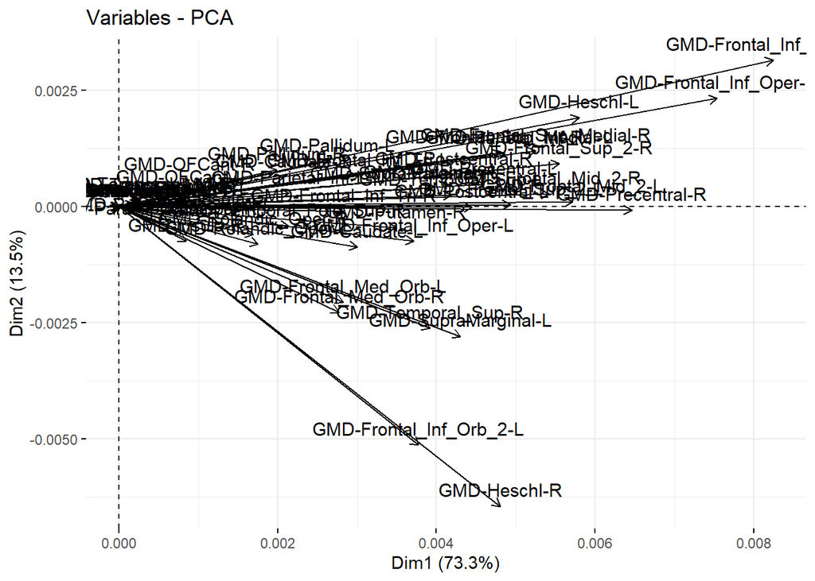

```r
### but...PC1 is only representing a few variables...
factoextra::fviz_pca_var(ready_pca_nostan, col.var='black')
```

```r
# remove labels

### PC1 is constructed to "explain" the direction with the most
### variation in the data set
### if we do not standardize...the "most variation" is just the
### variables with the largest variance!!!
```

```r
### the variables with the largest variance in the data set..
ready_wf %>% purrr::map_dbl(var)
```

```
##            GMD-Caudate-L            GMD-Caudate-R   GMD-Frontal_Inf_Oper-L
##             1.774934e-05             6.568496e-06             2.144930e-05
##   GMD-Frontal_Inf_Oper-R  GMD-Frontal_Inf_Orb_2-L  GMD-Frontal_Inf_Orb_2-R
##             6.740256e-05             4.670547e-05             9.010141e-05
##    GMD-Frontal_Inf_Tri-L    GMD-Frontal_Inf_Tri-R    GMD-Frontal_Med_Orb-L
##             1.049466e-05             8.957260e-06             1.488833e-05
##    GMD-Frontal_Med_Orb-R      GMD-Frontal_Mid_2-L      GMD-Frontal_Mid_2-R
##             1.616306e-05             3.405684e-05             3.066078e-05
##      GMD-Frontal_Sup_2-L      GMD-Frontal_Sup_2-R GMD-Frontal_Sup_Medial-L
##             2.531873e-05             3.222430e-05             2.639467e-05
## GMD-Frontal_Sup_Medial-R           GMD-Fusiform-L           GMD-Fusiform-R
##             3.052685e-05             1.426199e-11             1.129105e-15
##             GMD-Heschl-L             GMD-Heschl-R             GMD-Insula-L
##             4.080076e-05             6.909830e-05             2.315474e-06
##             GMD-Insula-R             GMD-OFCant-L             GMD-OFCant-R
##             1.544266e-06             1.096744e-06             2.298366e-06
##           GMD-Pallidum-L           GMD-Pallidum-R    GMD-ParaHippocampal-L
##             9.693363e-06             5.513757e-06             1.078942e-06
##    GMD-ParaHippocampal-R       GMD-Parietal_Inf-L       GMD-Parietal_Inf-R
##             7.513941e-07             7.121359e-06             3.343858e-05
##        GMD-Postcentral-L        GMD-Postcentral-R         GMD-Precentral-L
##             2.170768e-05             2.013675e-05             2.381347e-05
##         GMD-Precentral-R            GMD-Putamen-L            GMD-Putamen-R
##             4.646936e-05             1.938406e-05             1.418496e-05
##             GMD-Rectus-L             GMD-Rectus-R      GMD-Rolandic_Oper-L
##             1.072071e-09             1.170300e-09             7.921153e-06
##      GMD-Rolandic_Oper-R      GMD-SupraMarginal-L      GMD-SupraMarginal-R
##             4.507840e-06             3.279073e-05             1.416598e-05
##       GMD-Temporal_Inf-L       GMD-Temporal_Inf-R       GMD-Temporal_Mid-L
##             1.627566e-09             8.846362e-11             2.744815e-07
##       GMD-Temporal_Mid-R  GMD-Temporal_Pole_Mid-L  GMD-Temporal_Pole_Mid-R
##             2.026218e-07             8.721295e-13             6.599615e-09
##  GMD-Temporal_Pole_Sup-L  GMD-Temporal_Pole_Sup-R       GMD-Temporal_Sup-L
##             5.737146e-08             9.148554e-06             1.979380e-05
##       GMD-Temporal_Sup-R
##             2.422571e-05
```

```r
### easier to read in terms of the standard deviation
ready_wf %>% purrr::map_dbl(sd)
```

```
##            GMD-Caudate-L            GMD-Caudate-R   GMD-Frontal_Inf_Oper-L
##             4.212997e-03             2.562908e-03             4.631339e-03
##   GMD-Frontal_Inf_Oper-R  GMD-Frontal_Inf_Orb_2-L  GMD-Frontal_Inf_Orb_2-R
##             8.209906e-03             6.834140e-03             9.492176e-03
##    GMD-Frontal_Inf_Tri-L    GMD-Frontal_Inf_Tri-R    GMD-Frontal_Med_Orb-L
##             3.239546e-03             2.992868e-03             3.858540e-03
##    GMD-Frontal_Med_Orb-R      GMD-Frontal_Mid_2-L      GMD-Frontal_Mid_2-R
##             4.020331e-03             5.835824e-03             5.537218e-03
##      GMD-Frontal_Sup_2-L      GMD-Frontal_Sup_2-R GMD-Frontal_Sup_Medial-L
##             5.031772e-03             5.676645e-03             5.137574e-03
## GMD-Frontal_Sup_Medial-R           GMD-Fusiform-L           GMD-Fusiform-R
##             5.525110e-03             3.776504e-06             3.360215e-08
##             GMD-Heschl-L             GMD-Heschl-R             GMD-Insula-L
##             6.387548e-03             8.312539e-03             1.521668e-03
##             GMD-Insula-R             GMD-OFCant-L             GMD-OFCant-R
##             1.242685e-03             1.047255e-03             1.516036e-03
##           GMD-Pallidum-L           GMD-Pallidum-R    GMD-ParaHippocampal-L
##             3.113417e-03             2.348139e-03             1.038721e-03
##    GMD-ParaHippocampal-R       GMD-Parietal_Inf-L       GMD-Parietal_Inf-R
##             8.668299e-04             2.668587e-03             5.782610e-03
##        GMD-Postcentral-L        GMD-Postcentral-R         GMD-Precentral-L
##             4.659150e-03             4.487399e-03             4.879905e-03
##         GMD-Precentral-R            GMD-Putamen-L            GMD-Putamen-R
##             6.816844e-03             4.402734e-03             3.766293e-03
##             GMD-Rectus-L             GMD-Rectus-R      GMD-Rolandic_Oper-L
##             3.274249e-05             3.420965e-05             2.814454e-03
##      GMD-Rolandic_Oper-R      GMD-SupraMarginal-L      GMD-SupraMarginal-R
##             2.123168e-03             5.726319e-03             3.763771e-03
##       GMD-Temporal_Inf-L       GMD-Temporal_Inf-R       GMD-Temporal_Mid-L
##             4.034310e-05             9.405510e-06             5.239098e-04
##       GMD-Temporal_Mid-R  GMD-Temporal_Pole_Mid-L  GMD-Temporal_Pole_Mid-R
##             4.501353e-04             9.338787e-07             8.123802e-05
##  GMD-Temporal_Pole_Sup-L  GMD-Temporal_Pole_Sup-R       GMD-Temporal_Sup-L
##             2.395234e-04             3.024658e-03             4.449023e-03
##       GMD-Temporal_Sup-R
##             4.921962e-03
```

The GMD-Frontal_Inf_Orb_2-R had the most variation according to sd values above

we should standardize so the natural units do not impact the interpretation

Second interpretation: MODEL of the data

can consider the RECONSTRUCTION ERROR or approximation error of the original variables based on a specified number of PCs

define a function to reconstruct the original data set for a given number of PCs to retain

```r
my_reconstruct <- function(nComp, pca_obj)
{
  # extract the scores
  z_mat <- pca_obj$x[, 1:nComp, drop=FALSE]

  # extract the loadings matrix
  phi_mat <- pca_obj$rotation[, 1:nComp, drop = FALSE]

  # reconstruct the standardized variables
  xhat <- z_mat %*% t(phi_mat)

  # rescale the reconstructed variables
  xhat <- scale(xhat, center = FALSE, scale = 1/pca_obj$scale)

  # add back the means
  scale(xhat, center = -pca_obj$center, scale = FALSE)
}
```

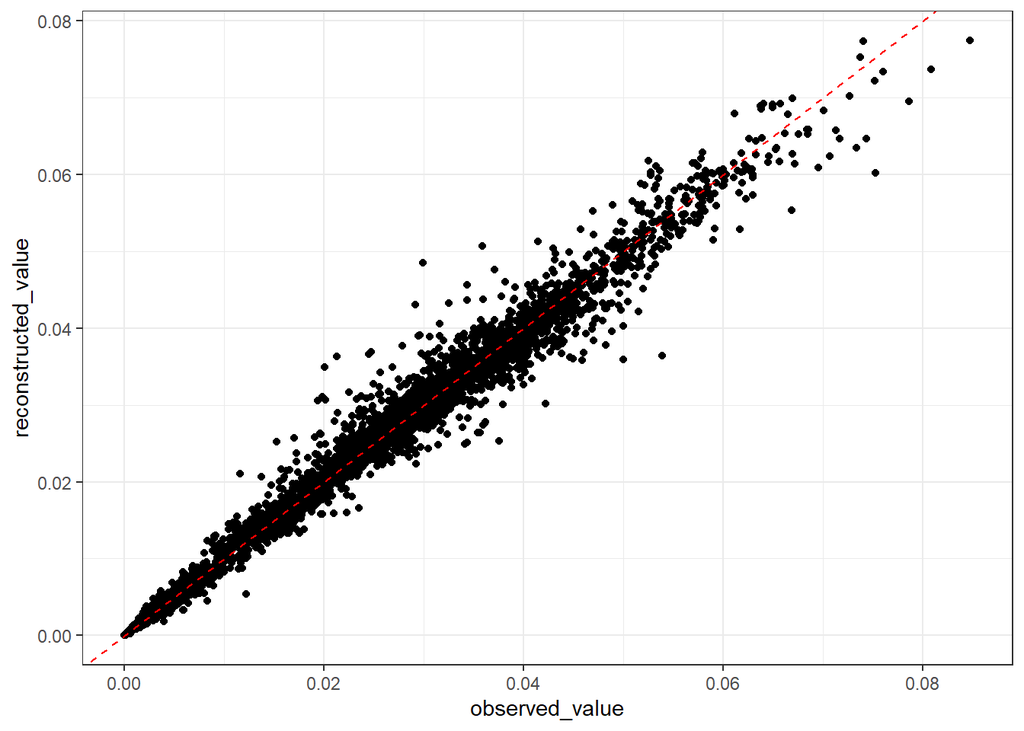

```r
my_reconstruct(1, ready_pca) %>%
  as.data.frame() %>% tibble::rownames_to_column() %>%
  pivot_longer(!c("rowname"), values_to = "reconstructed_value") %>%
  left_join(ready_wf %>%
              tibble::rownames_to_column() %>%
              pivot_longer(!c("rowname"), values_to = "observed_value"),
            by = c("name", "rowname")) %>%
  ggplot(mapping = aes(x = observed_value, y = reconstructed_value)) +
  geom_point(color = "black") +
  geom_abline(slope = 1, intercept = 0,
              color = "red", linetype = "dashed") +
  #facet_wrap(~name, scales = "free") +
  theme_bw()
```

Instead of looking at a reconstructed-vs-observed plot, summarize the absolute reconstruction error per region.

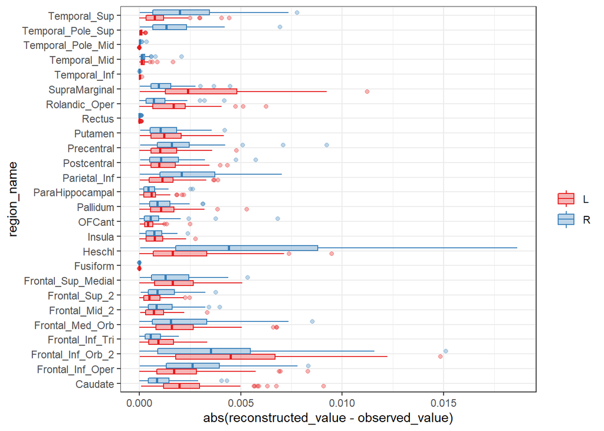

```r
my_reconstruct(1, ready_pca) %>%
  as.data.frame() %>% tibble::rownames_to_column() %>%
  pivot_longer(!c("rowname"), values_to = "reconstructed_value") %>%
  left_join(ready_wf %>%
              tibble::rownames_to_column() %>%
              pivot_longer(!c("rowname"), values_to = "observed_value"),
            by = c("name", "rowname")) %>%
  tidyr::separate(name,
                  c("result_name", "region_name", "side_name"),
                  sep = "-") %>%
  ggplot(mapping = aes(y = region_name,
                       x = abs(reconstructed_value - observed_value))) +
  geom_boxplot(mapping = aes(group = interaction(result_name,
                                                 region_name,
                                                 side_name),
                             fill = side_name,
                             color = side_name),
               alpha = 0.33) +
  scale_fill_brewer("", palette = "Set1") +
  scale_color_brewer("", palette = "Set1") +
  theme_bw()
```

Include 7 PCs in the reconstruction.

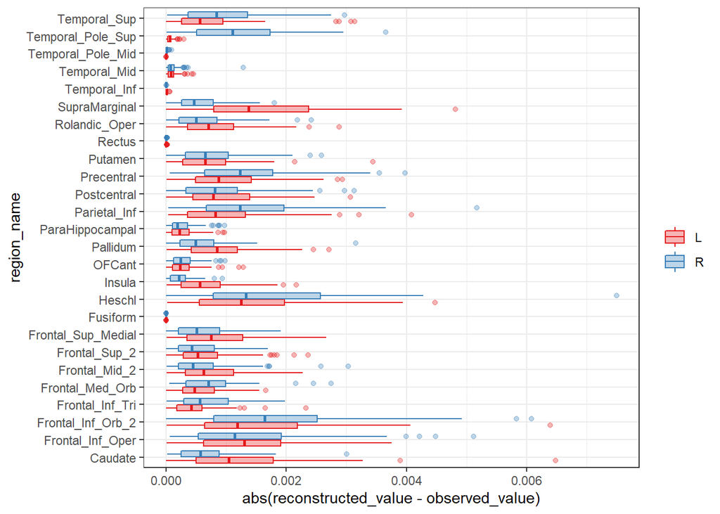

```r
my_reconstruct(7, ready_pca) %>%
  as.data.frame() %>% tibble::rownames_to_column() %>%
  pivot_longer(!c("rowname"), values_to = "reconstructed_value") %>%
  left_join(ready_wf %>%
              tibble::rownames_to_column() %>%
              pivot_longer(!c("rowname"), values_to = "observed_value"),
            by = c("name", "rowname")) %>%
  tidyr::separate(name,
                  c("result_name", "region_name", "side_name"),
                  sep = "-") %>%
  ggplot(mapping = aes(y = region_name,
                       x = abs(reconstructed_value - observed_value))) +
  geom_boxplot(mapping = aes(group = interaction(result_name,
                                                 region_name,
                                                 side_name),
                             fill = side_name,
                             color = side_name),
               alpha = 0.33) +
  scale_fill_brewer("", palette = "Set1") +
  scale_color_brewer("", palette = "Set1") +
  theme_bw()
```

Directly compare reconstruction error between number of PCs retained.

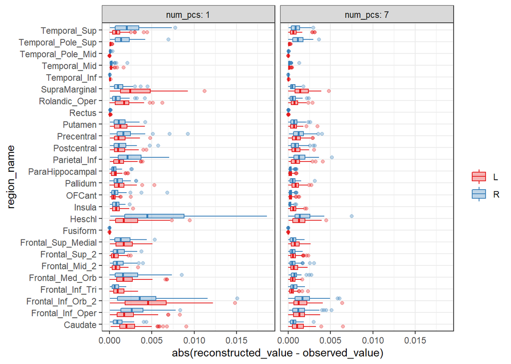

```r
my_reconstruct(1, ready_pca) %>%
  as.data.frame() %>% tibble::rownames_to_column() %>%
  pivot_longer(!c("rowname"), values_to = "reconstructed_value") %>%
  left_join(ready_wf %>%
              tibble::rownames_to_column() %>%
              pivot_longer(!c("rowname"), values_to = "observed_value"),
            by = c("name", "rowname")) %>%
  tidyr::separate(name,
                  c("result_name", "region_name", "side_name"),
                  sep = "-") %>%
  mutate(num_pcs = 1) %>%
  bind_rows(my_reconstruct(7, ready_pca) %>%
  as.data.frame() %>% tibble::rownames_to_column() %>%
  pivot_longer(!c("rowname"), values_to = "reconstructed_value") %>%
  left_join(ready_wf %>%
              tibble::rownames_to_column() %>%
              pivot_longer(!c("rowname"), values_to = "observed_value"),
            by = c("name", "rowname")) %>%
  tidyr::separate(name,
                  c("result_name", "region_name", "side_name"),
                  sep = "-") %>%
    mutate(num_pcs = 7)) %>%
  ggplot(mapping = aes(y = region_name,
                       x = abs(reconstructed_value - observed_value))) +
  geom_boxplot(mapping = aes(group = interaction(result_name,
                                                 region_name,
                                                 side_name,
                                                 num_pcs),
                             fill = side_name,
                             color = side_name),
               alpha = 0.33) +
  facet_wrap(~num_pcs, labeller = 'label_both') +
  scale_fill_brewer("", palette = "Set1") +
  scale_color_brewer("", palette = "Set1") +
  theme_bw()
```

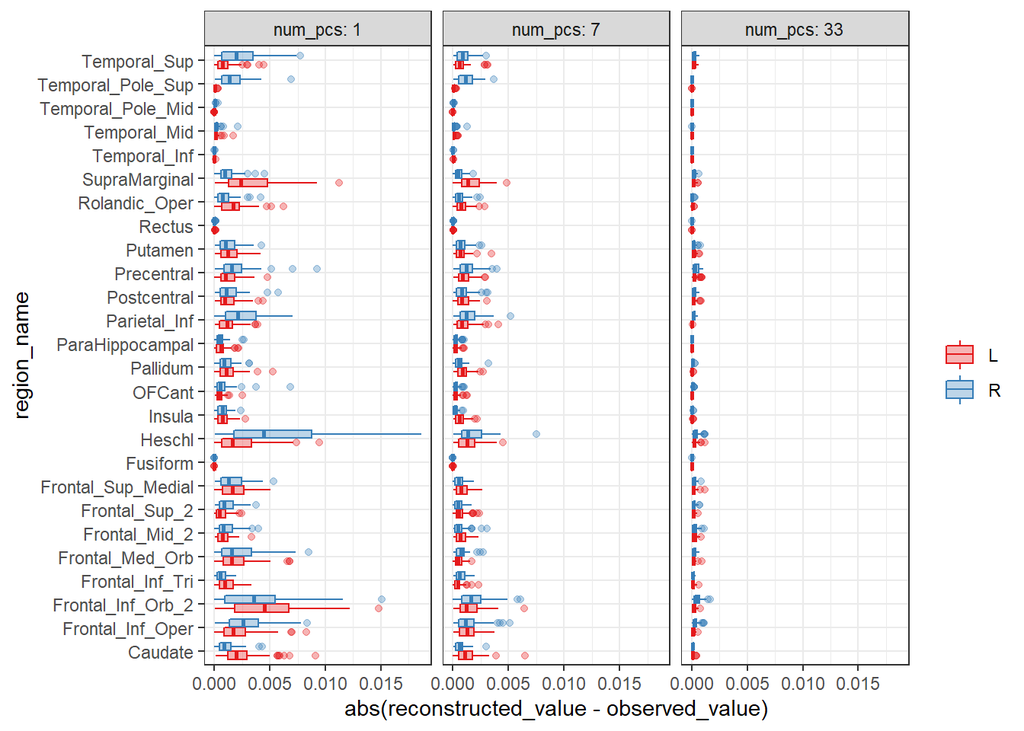

```r
my_reconstruct(1, ready_pca) %>%
  as.data.frame() %>% tibble::rownames_to_column() %>%
  pivot_longer(!c("rowname"), values_to = "reconstructed_value") %>%
  left_join(ready_wf %>%
              tibble::rownames_to_column() %>%
              pivot_longer(!c("rowname"), values_to = "observed_value"),
            by = c("name", "rowname")) %>%
  tidyr::separate(name,
                  c("result_name", "region_name", "side_name"),
                  sep = "-") %>%
  mutate(num_pcs = 1) %>%
  bind_rows(my_reconstruct(7, ready_pca) %>%
  as.data.frame() %>% tibble::rownames_to_column() %>%
  pivot_longer(!c("rowname"), values_to = "reconstructed_value") %>%
  left_join(ready_wf %>%
              tibble::rownames_to_column() %>%
              pivot_longer(!c("rowname"), values_to = "observed_value"),
            by = c("name", "rowname")) %>%
  tidyr::separate(name,
                  c("result_name", "region_name", "side_name"),
                  sep = "-") %>%
    mutate(num_pcs = 7)) %>%
  bind_rows(my_reconstruct(33, ready_pca) %>%
  as.data.frame() %>% tibble::rownames_to_column() %>%
  pivot_longer(!c("rowname"), values_to = "reconstructed_value") %>%
  left_join(ready_wf %>%
              tibble::rownames_to_column() %>%
              pivot_longer(!c("rowname"), values_to = "observed_value"),
            by = c("name", "rowname")) %>%
  tidyr::separate(name,
                  c("result_name", "region_name", "side_name"),
                  sep = "-") %>%
    mutate(num_pcs = 33)) %>%
  ggplot(mapping = aes(y = region_name,
                       x = abs(reconstructed_value - observed_value))) +
  geom_boxplot(mapping = aes(group = interaction(result_name,
                                                 region_name,
                                                 side_name,
                                                 num_pcs),
                             fill = side_name,
                             color = side_name),
               alpha = 0.33) +
  facet_wrap(~num_pcs, labeller = 'label_both') +
  scale_fill_brewer("", palette = "Set1") +
  scale_color_brewer("", palette = "Set1") +
  theme_bw()
```

Couldn’t visualize with facet wrap because of 52 PCA. Better way to visualize reconstructed versus observed value?

[figure not shown]

```r
### reconstruct based on the first two PCs
my_reconstruct(2, ready_pca) %>%
  as.data.frame() %>% tibble::rownames_to_column() %>%
  pivot_longer(!c("rowname"), values_to = "reconstructed_value") %>%
  left_join(ready_wf %>%
              tibble::rownames_to_column() %>%
              pivot_longer(!c("rowname"), values_to = "observed_value"),
            by = c("name", "rowname")) %>%
  ggplot(mapping = aes(x = observed_value, y = reconstructed_value)) +
  geom_point(color = "black") +
  geom_abline(slope = 1, intercept = 0,
              color = "red", linetype = "dashed") +
  facet_wrap(~name, scales = "free") +
  theme_bw()
```

Reformatting to better visualize facet wrap? Can’t tell what is going on between reconstructed and observed values. Do points along the red line indicate that the reconstructed value is the same as the observed value?

[figure not shown]

```r
### reconstruct based on the first 3 PCs
my_reconstruct(3,ready_pca) %>%
  as.data.frame() %>% tibble::rownames_to_column() %>%
  pivot_longer(!c("rowname"), values_to = "reconstructed_value") %>%
  left_join(ready_wf %>%
              tibble::rownames_to_column() %>%
              pivot_longer(!c("rowname"), values_to = "observed_value"),
            by = c("name", "rowname")) %>%
  ggplot(mapping = aes(x = observed_value, y = reconstructed_value)) +
  geom_point(color = "black") +
  geom_abline(slope = 1, intercept = 0,
              color = "red", linetype = "dashed") +
  facet_wrap(~name, scales = "free") +
  theme_bw()
```

Having difficulty visualize facet wraps

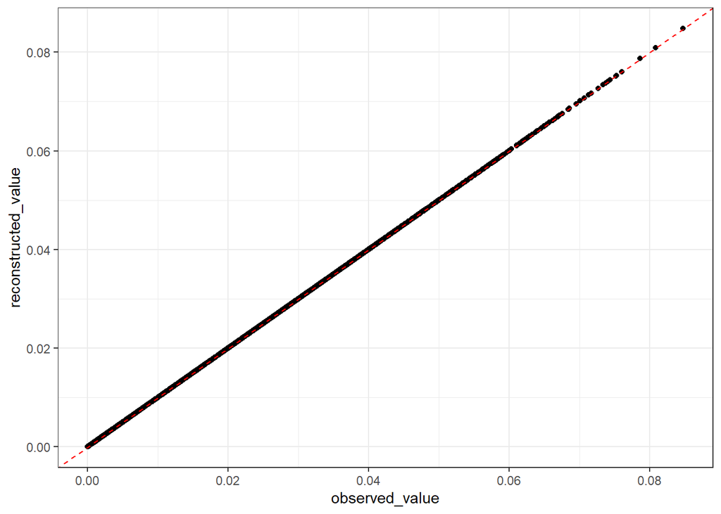

```r
### what happens if we use ALL PCs??
my_reconstruct(ncol(ready_pca$x), ready_pca) %>%
  as.data.frame() %>% tibble::rownames_to_column() %>%
  pivot_longer(!c("rowname"), values_to = "reconstructed_value") %>%
  left_join(ready_wf %>%
              tibble::rownames_to_column() %>%
              pivot_longer(!c("rowname"), values_to = "observed_value"),
            by = c("name", "rowname")) %>%
  ggplot(mapping = aes(x = observed_value, y = reconstructed_value)) +
  geom_point(color = "black") +
  geom_abline(slope = 1, intercept = 0,
              color = "red", linetype = "dashed") +
  #facet_wrap(~name, scales = "free") +
  theme_bw()
```

The reconstructed values all fall onto the dashed line. Perfect reconstruction but no dimension reduction. Find a balance. Total variance is somewhat explained by the reconstruction error. More PC capture more variance. Eigenvalues and fraction variance tells us more

```r
library(ggfortify)
```

```r
# Generate heat map for PCA 2 vs PCA 1

gmd_pca_plot <-autoplot((ready_pca),color = 'Species')
```

```r
# wasn't able to generate this heatmap

aa<- grep("grey",colors())
bb<- grep("green",colors())
cc<-  grep("red",colors())
gcol2<- colors()[c(aa[1:30],bb[1:20],rep(cc,2))]

## use the weights from PC1.

pca1_object <- my_reconstruct(1, ready_pca)
ord1<- order(abs(pca1_object), decreasing=TRUE)
x1<- as.matrix(ord1[1:52])
x1
```

```
##       [,1]
##  [1,]  495
##  [2,]  325
##  [3,] 2875
##  [4,]  329
##  [5,]  499
##  [6,] 2879
##  [7,]  290
##  [8,]  258
##  [9,]  460
## [10,]  428
## [11,]  272
## [12,] 2840
## [13,] 2808
## [14,]  278
```

[output cut: 38 more lines]

```r
#heatmap(x1,col=gcol2)
```

```r
vst_cor <- as.matrix(cor(ready_pca$x, method="spearman"))
library(pheatmap)
library(RColorBrewer)

vst_cor
```

[output not shown]

[output cut: 528 more lines]

[output not shown]

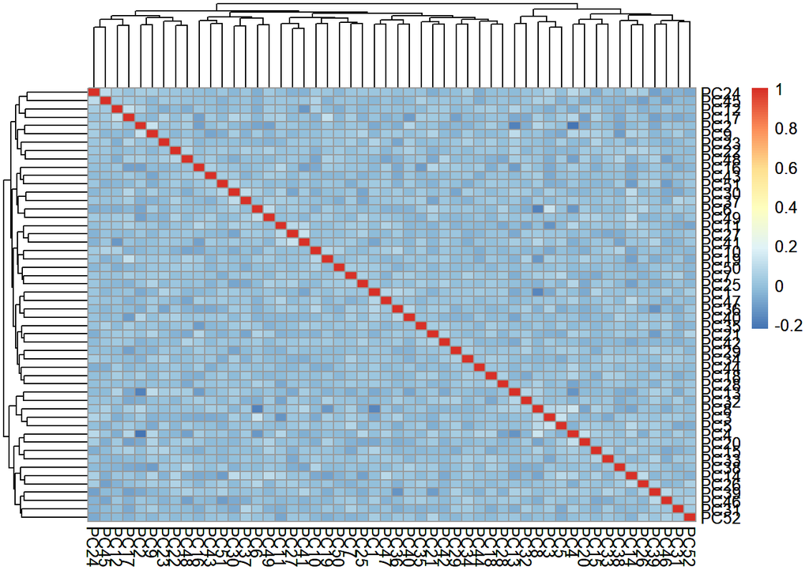

```r
heat_map_plot <- pheatmap(vst_cor, color =  colorRampPalette(rev(brewer.pal(n = 7, name =
  "RdYlBu")))(100), kmeans_k = NA, breaks = NA, border_color = "grey60", cluster_rows = TRUE,
  cluster_cols = TRUE, clustering_distance_rows = "euclidean",
  clustering_distance_cols = "euclidean", clustering_method = "complete")


heat_map_plot
```

```r
contribution_plot <- factoextra::fviz_contrib(ready_pca, choice = 'var', axes = 1, tl.pos = 'n')


# how do I identify the threshold (horizontal value) (I used 1.75)

contribution_plot$data %>% glimpse()
```

```
## Rows: 52
## Columns: 2
## $ name    <fct> GMD-Caudate-L, GMD-Caudate-R, GMD-Frontal_Inf_Oper-L, GMD-Fron~
## $ contrib <dbl> 1.73476969, 2.24174118, 2.09046604, 2.55939785, 0.89298505, 2.~
```

```r
# encode all active values as 1 and encode all inactive values as 0

pca1_activation <- contribution_plot$data %>% mutate(active_status = ifelse(contribution_plot$data$contrib > 1.75, 1, 0))

# what regions are active for pc1?
```

```r
library(dplyr)
library(ggseg)
```

```r
#gmd_avg_person_wf

# Need to separate regions in gmd_avg_person_wf into groups

# g1 -- Frontal regions
# g2 -- Temporal
# g3 --

#someData <- tibble(
 # region = rep(c("transverse temporal", "insula",
#           "precentral","superior parietal"), 2),
 # p = sample(seq(0,.5,.001), 8),
#  groups = c(rep("g1", 4), rep("g2", 4))
#)

#gmd_avg_person_wf %>%
 # ggplot() +
 # geom_brain(atlas = dk,
           #  position = position_brain(hemi ~ side),
          #   aes(fill = values)) +
  #facet_wrap(~groups)
```

[output not shown]